# Exploring the U.S. National Oceanic and Atmospheric Administration’s (NOAA) storm database

================================================================================================================

### Synopsis

Storms and other severe weather events can cause both public health and economic problems for communities and municipalities. Many severe events can result in fatalities, injuries, and property damage, and preventing such outcomes to the extent possible is a key concern.

This report involves exploring the U.S. National Oceanic and Atmospheric Administration’s (NOAA) storm database. This database tracks characteristics of major storms and weather events in the United States, including when and where they occur, as well as estimates of any fatalities, injuries, and property damage.

### Data Processing

In this section we will describe the process that we follow to make our data meaningfull.

We would like to extract two results. The first relates to the population health. In greater detail, across the United States, we are interested in finding which types of events are most harmful. The second relates to the economic consequences. Concretely, across the United States, which types of events have the greatest economic consequences.

##### Population Health

```r
library(plyr)
data<-read.csv("repdata-data-StormData.csv.bz2")

cdata <- ddply(data, c("EVTYPE"), summarise, numberofEVENT=length(FATALITIES),sumFatalities = sum(FATALITIES),
 meanFatalities = mean(FATALITIES),sumInjuries   = sum(INJURIES),meanInjuries = mean(INJURIES) )
```

```r
newdata<-subset(cdata, cdata$numberofEVENT>100)

newdata<-newdata[order(-newdata$meanFatalities, -newdata$meanInjuries),]
```

Then we took the first 20 events

```r
newdata[1:20,]
```

```
##                      EVTYPE numberofEVENT sumFatalities meanFatalities
## 275                    HEAT           767           937        1.22164
## 130          EXCESSIVE HEAT          1678          1903        1.13409
## 585             RIP CURRENT           470           368        0.78298
## 586            RIP CURRENTS           304           204        0.67105
## 19                AVALANCHE           386           224        0.58031
## 402               HURRICANE           174            61        0.35057
## 140            EXTREME COLD           655           160        0.24427
## 342    HEAVY SURF/HIGH SURF           228            42        0.18421
## 79          COLD/WIND CHILL           539            95        0.17625
## 350               HIGH SURF           725           101        0.13931
## 141 EXTREME COLD/WIND CHILL          1002           125        0.12475
## 188                     FOG           538            62        0.11524
## 834                 TORNADO         60652          5633        0.09287
## 886       UNSEASONABLY WARM           126            11        0.08730
```

[output cut: 27 more lines]

##### Economic Consequencies

The process for the economic consequencies is the similar with the above. Firstly, we split the data per event and we calculate our metrics. Then we found the units of measurement for the damnage. the variable ‘propdmgexp’ has all the units. We are only interested in B, M, K. Then we want to add the two costs: property and corp But we cannot do that immediately since some of them are in different units.

```r
library(plyr)

s<-split(data, data$PROPDMGEXP)

propdmgexp<-names(s)

sub<-subset(data, data$PROPDMGEXP=="B" | data$PROPDMGEXP=="M" | data$PROPDMGEXP=="K" | data$CROPDMGEXP=="B" | data$CROPDMGEXP=="M" | data$CROPDMGEXP=="K"  )
```

Then i use ddply in order to take per event the sum of cost and the mean of cost.

```r
f<-function(x, y, z, w) (
  if (x=="B" & y=="B") { z+w }
  else if ( x=="M" & y=="B") { (z/1000)+ w }
  else if (x=="K" & y=="B") { (z/1000000)+ w }
  else if (x=="B" & y=="M") { (w/1000)+z }
  else if (x=="B" & y=="K") { (w/1000000)+ z}
  else if (x=="B") { z}
  else   w
  )

sub$total<-mapply(f, sub$PROPDMGEXP, sub$CROPDMGEXP, sub$PROPDMG, sub$CROPDMG)

newedata <- ddply(sub, c("EVTYPE"), summarise, numberofEVENT=length(FATALITIES),sumtotal = sum(total), meantotal=mean(total) )

newedata<-subset(newedata, newedata$numberofEVENT>100)

newedata<-newedata[order(-newedata$meantotal),]
```

The events with the largest economic consequencies are

```r
newedata[1:20,]
```

```
##                   EVTYPE numberofEVENT sumtotal meantotal
## 185            HURRICANE           128   4544.8    35.506
## 53          EXTREME COLD           187   6121.1    32.733
## 259          RIVER FLOOD           107   3495.0    32.664
## 38               DROUGHT          1526  33898.6    22.214
## 66        FLASH FLOODING           293   5126.1    17.495
## 410     WILD/FOREST FIRE           325   4191.0    12.896
## 360       TROPICAL STORM           573   5904.3    10.304
## 380       TSTM WIND/HAIL           436   4356.6     9.992
## 70                 FLOOD         17468 168126.9     9.625
## 95          FROST/FREEZE          1033   7034.1     6.809
## 44            DUST STORM           238   1601.5     6.729
## 391          URBAN FLOOD           140    923.5     6.596
## 113                 HAIL         94305 579578.1     6.146
## 298     STORM SURGE/TIDE           145    854.0     5.890
## 58           FLASH FLOOD         32999 179201.5     5.431
## 74     FLOOD/FLASH FLOOD           274   1427.7     5.211
## 397 URBAN/SML STREAM FLD           727   2793.8     3.843
## 178           HIGH WINDS           607   1759.6     2.899
## 412             WILDFIRE          1991   4358.7     2.189
## 351              TORNADO         52039 100023.8     1.922
```

### Results

The following chart shows the first 20 more fatal events.

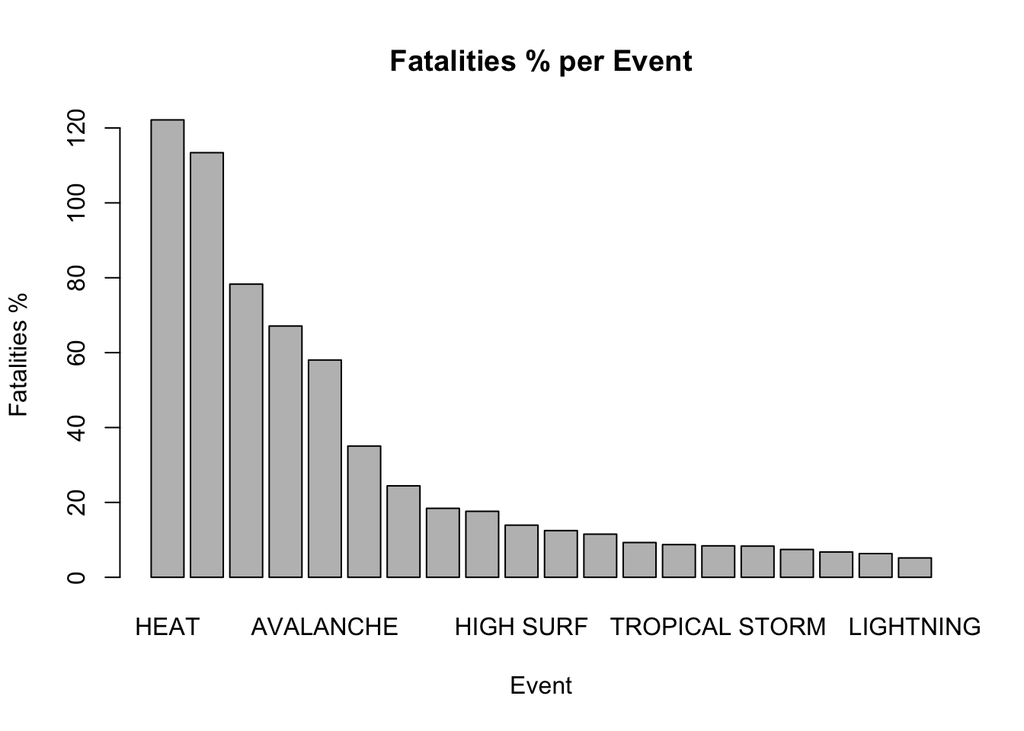

```r
barplot(newdata[1:20, ]$meanFatalities*100, main="Fatalities % per Event",xlab="Event", names.arg=newdata[1:20, ]$EVTYPE, ylab="Fatalities % ")
```

The next chart shows the first 20 events with the greatest economic consequences

[figure not shown]

```r
barplot(newedata[1:20, ]$meantotal, main="Mean cost per Event",xlab="Event", names.arg=newdata[1:20, ]$EVTYPE, ylab="mean cost")
```